# DEI Symbolic/Substantive Study: Technical Appendix

Casey McMahon

2026-05-14

# DEI Symbolic/Substantive Study: Technical Appendix

This appendix reports the analyses for a study examining whether people distinguish between DEI actions that primarily communicate organizational values and DEI actions that appear more concrete, structural, or resource-backed. Participants rated a set of DEI policies on a 0–100 symbolic-to-substantive scale, where higher values indicate that the policy was perceived as more substantive.

## Load analytic data

This technical appendix assumes the private cleaning file has already been run and saved a de-identified analytic dataset.

```r
data <- read_csv("~/Documents/github/casey-portfolio-site/assets/files/dei-rollbacks/data/dei-symbolic-substantive-cleaned.csv")
```

## Study design

Participants evaluated 25 DEI policies on a 0–100 scale. The scale was coded so that lower values indicate that a policy was perceived as more symbolic, while higher values indicate that a policy was perceived as more substantive. This study serves as the first step in the broader project by testing whether people perceive meaningful differences among DEI actions before evaluating how organizations maintain or change their commitments.

## Sample characteristics

Final analytic sample

| Final analytic N |
| --- |
| 358 |

Participant gender

| Gender | N | Percent |
| --- | --- | --- |
| Man | 150 | 41.9% |
| Woman | 204 | 57.0% |
| Another gender | 4 | 1.1% |

Participant race

| Race | N | Percent |
| --- | --- | --- |
| White | 262 | 73.2% |
| Asian | 30 | 8.4% |
| Black | 23 | 6.4% |
| Hispanic/ Latino/a | 20 | 5.6% |
| Native American | 1 | 0.3% |
| Middle Eastern | 1 | 0.3% |
| Bi/ multiracial | 20 | 5.6% |
| Another race | 1 | 0.3% |

Participant age

| N | M | SD | Min | Max |
| --- | --- | --- | --- | --- |
| 357 | 42.17 | 14.38 | 18.00 | 83.00 |

## Policy labels

```r
policy_labels <- c(
  p01 = "Inclusive language",
  p02 = "Inclusive meeting norms",
  p03 = "Chosen names and pronouns",
  p04 = "Employee Resource Groups",
  p05 = "DEI goals and metrics",
  p06 = "Recruiting pipelines",
  p07 = "Diverse candidate slates",
  p08 = "DEI training",
  p09 = "Accessibility policy",
  p10 = "DEI audits",
  p11 = "Structured interviews",
  p12 = "Blind résumé review",
  p13 = "Pay ranges",
  p14 = "Accommodation process",
  p15 = "Inclusive facilities",
  p16 = "Paid leave",
  p17 = "Flexible work",
  p18 = "Mentorship/sponsorship",
  p19 = "Leader compensation tied to DEI",
  p20 = "Safe reporting channels",
  p21 = "Annual diversity statements",
  p22 = "Heritage-month celebrations",
  p23 = "DEI webpage",
  p24 = "Inclusive signage",
  p25 = "DEI town halls"
)

policy_vars <- names(policy_labels)
```

## Perceived substantiveness of DEI policies

The primary descriptive analysis ranks the 25 DEI policies by their mean perceived substantiveness. This plot is the clearest summary of the study: it shows which actions were perceived as relatively symbolic versus relatively substantive.

```r
summary_by_policy <- data %>%
  dplyr::select(ppid, dplyr::all_of(policy_vars)) %>%
  tidyr::pivot_longer(
    cols = dplyr::all_of(policy_vars),
    names_to = "policy",
    values_to = "substantiveness"
  ) %>%
  dplyr::mutate(substantiveness = as.numeric(substantiveness)) %>%
  dplyr::filter(!is.na(substantiveness)) %>%
  dplyr::group_by(policy) %>%
  dplyr::summarise(
    N = dplyr::n_distinct(ppid),
    M = mean(substantiveness, na.rm = TRUE),
    Median = median(substantiveness, na.rm = TRUE),
    SD = sd(substantiveness, na.rm = TRUE),
    SE = SD / sqrt(N),
    ci_lower = M - qt(.975, df = N - 1) * SE,
    ci_upper = M + qt(.975, df = N - 1) * SE,
    .groups = "drop"
  ) %>%
  dplyr::mutate(
    Policy = dplyr::recode(policy, !!!policy_labels),
    Policy = forcats::fct_reorder(Policy, M)
  ) %>%
  dplyr::arrange(M)
```

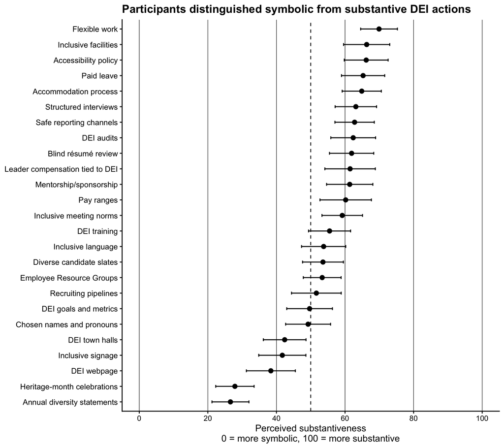

The ranked plot shows that participants differentiated among DEI policies rather than treating all actions as equivalent. Policies involving concrete structures, resources, or accountability tended to be rated as more substantive, whereas public-facing signals and communications tended to be rated as more symbolic.

```r
ggsave(
  filename = "../assets/img/dei-symbolic-substantive-ranked-policies.png",
  plot = ranked_policy_plot,
  width = 9,
  height = 8,
  dpi = 300
)
```

Perceived substantiveness ratings by policy

| Policy | N | M | Median | SD | 95% CI |
| --- | --- | --- | --- | --- | --- |
| Annual diversity statements | 85 | 26.59 | 22.00 | 24.99 | [21.20, 31.98] |
| Heritage-month celebrations | 92 | 27.89 | 23.00 | 27.01 | [22.30, 33.48] |
| DEI webpage | 83 | 38.37 | 29.00 | 32.69 | [31.24, 45.51] |
| Inclusive signage | 84 | 41.71 | 37.50 | 31.66 | [34.84, 48.58] |
| DEI town halls | 87 | 42.40 | 36.00 | 29.18 | [36.18, 48.62] |
| Chosen names and pronouns | 98 | 49.23 | 45.00 | 32.67 | [42.68, 55.78] |
| DEI goals and metrics | 93 | 49.67 | 48.00 | 32.35 | [43.00, 56.33] |
| Recruiting pipelines | 75 | 51.64 | 54.00 | 31.47 | [44.40, 58.88] |
| Employee Resource Groups | 96 | 53.34 | 55.50 | 27.20 | [47.83, 58.86] |
| Diverse candidate slates | 97 | 53.57 | 59.00 | 29.51 | [47.62, 59.51] |
| Inclusive language | 90 | 53.77 | 59.00 | 30.77 | [47.32, 60.21] |
| DEI training | 79 | 55.49 | 60.00 | 27.35 | [49.37, 61.62] |
| Inclusive meeting norms | 85 | 59.19 | 65.00 | 27.41 | [53.28, 65.10] |
| Pay ranges | 84 | 60.19 | 73.50 | 34.53 | [52.70, 67.68] |
| Mentorship/sponsorship | 90 | 61.37 | 74.50 | 32.18 | [54.63, 68.11] |
| Leader compensation tied to DEI | 73 | 61.48 | 70.00 | 31.53 | [54.12, 68.84] |
| Blind résumé review | 75 | 61.92 | 66.00 | 28.04 | [55.47, 68.37] |
| DEI audits | 78 | 62.38 | 66.50 | 28.94 | [55.86, 68.91] |
| Safe reporting channels | 86 | 62.79 | 67.00 | 26.76 | [57.05, 68.53] |
| Structured interviews | 84 | 63.15 | 73.00 | 27.83 | [57.12, 69.19] |
| Accommodation process | 94 | 64.87 | 68.50 | 27.87 | [59.16, 70.58] |
| Paid leave | 89 | 65.27 | 72.00 | 29.90 | [58.97, 71.57] |
| Accessibility policy | 86 | 66.17 | 73.00 | 29.84 | [59.78, 72.57] |
| Inclusive facilities | 90 | 66.31 | 75.00 | 32.14 | [59.58, 73.04] |
| Flexible work | 75 | 69.92 | 76.00 | 23.28 | [64.56, 75.28] |